# 360-Homework1

Safiye Şahin

13 11 2020

# HISTOGRAMS AND BOXPLOTS OF DIFFERENT DATASETS AND RELATED GOOGLE TRENDS VALUES

## Total clothing and Accessories Expenditures Made via Credit Card and Debit Card Data of Turkey over 2016-2019

*Year by Year Histograms*

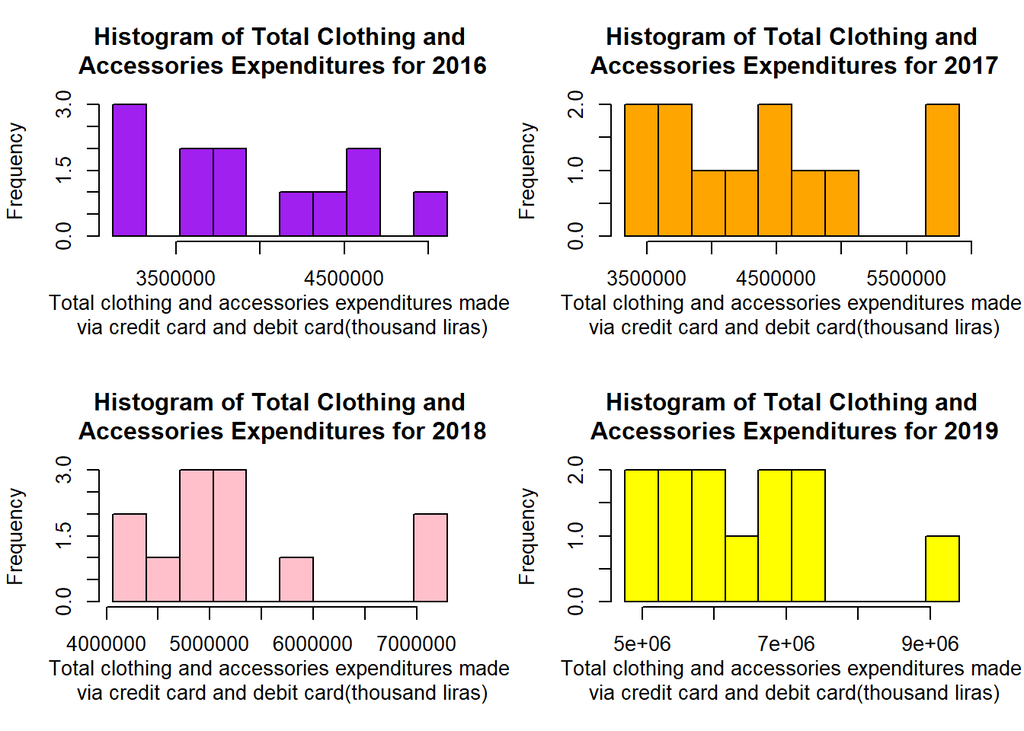

The data was examined for all years on a single boxplot in order to better observe the change between years and data intervals.

*Boxplot of data*

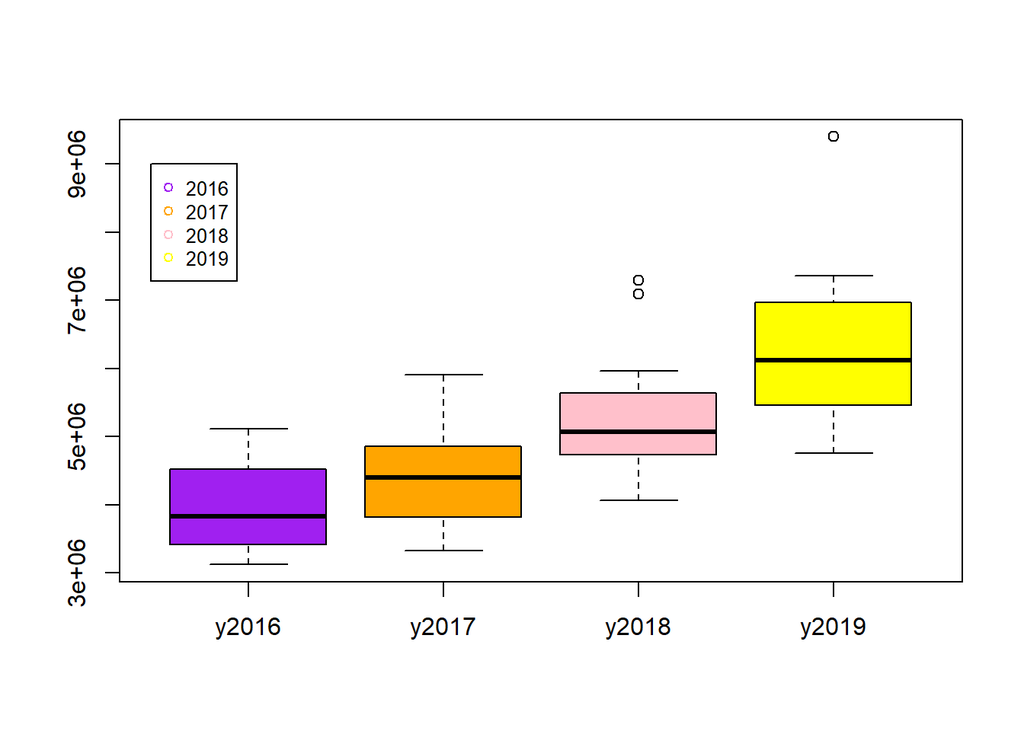

When this boxplot is examined, it can be easily observed that the aforementioned expenditures increase over the years.

[Google Trends](http://trends.google.com/) was used to find another data set that could follow a similar distribution with the distribution of the received data. In order to observe the share of trendyol, which is a prominent e-commerce page especially in the field of clothing shopping in recent years, and to determine whether it has a guiding effect, monthly data were obtained from Google trends for the frequency of searching for the word “trendyol” between 2016-2019. And this data is placed in a boxplot to compare annual changes.

[figure not shown]

## Total Tourism Expenditures(000$)

This data set contains the information of the total tourism expenditures by months in the Turkey between 2016 and 2019 years. Since the tourism sector is a sector that experiences fluctuations due to various climatic, political, environmental and many other variables throughout the year, the total expenditure on this sector and its monthly change over years can provide a data set worth examining.In order to examine the change in the data, the information is placed in separate histograms for each year. Check [Here](https://data.tuik.gov.tr/Kategori/GetKategori?p=egitim-kultur-spor-ve-turizm-105&dil=1) for extra information.

*Year by Year Histograms*

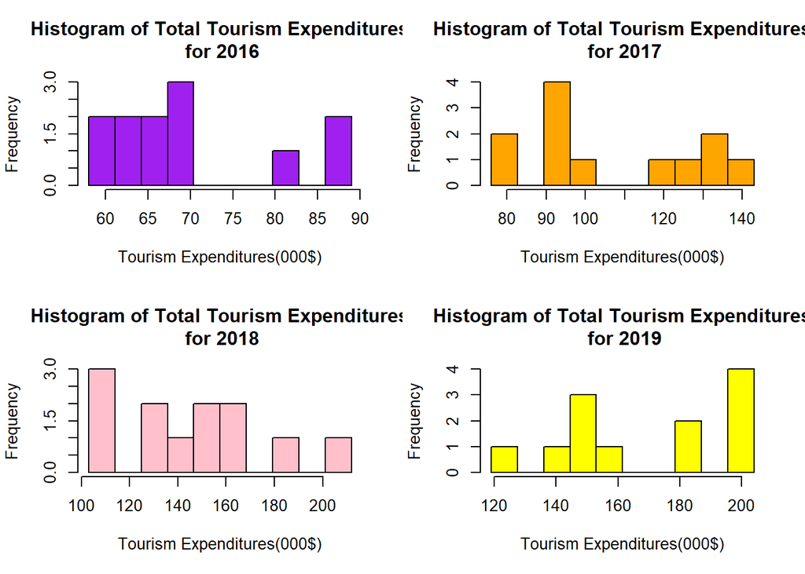

The data was examined for all years on a single boxplot in order to better observe the change between years and data intervals.

*Boxplot of data*

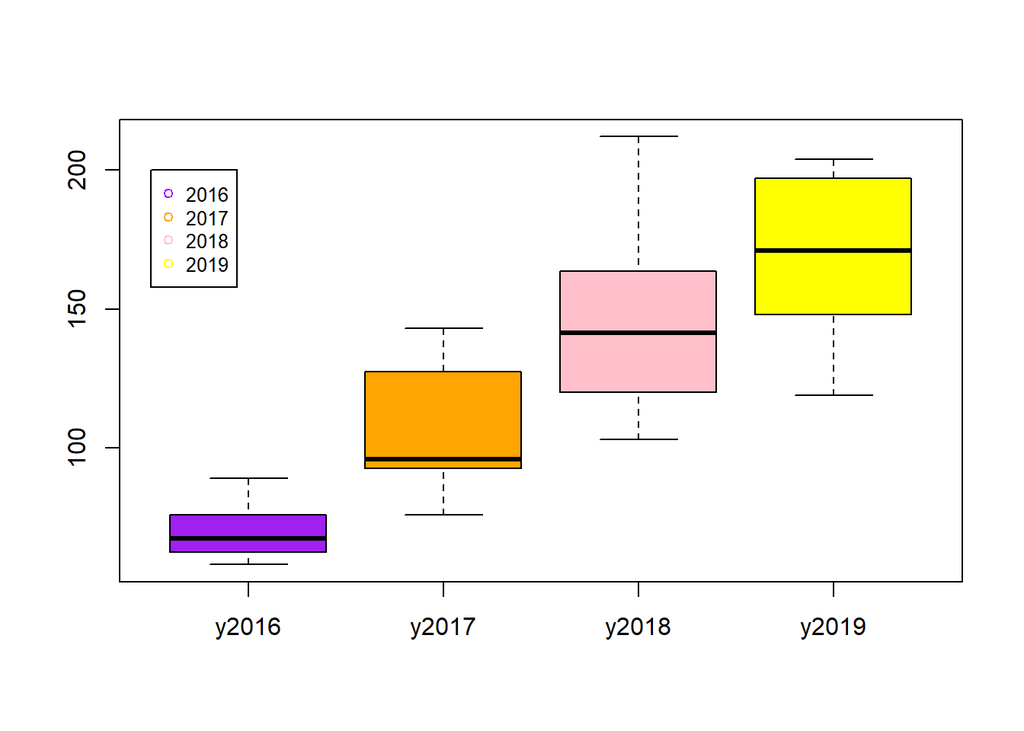

[Google Trends](http://trends.google.com/) data can be used to investigate the link between these expenditures and hotels and indirectly to obtain information on the share of hotel expenditures in these expenditures.For this purpose, monthly search volume data for the “otel” word was obtained from Google Trends between 2016 and 2019 and placed on a boxplot.

*Boxplot of Google Trends data*

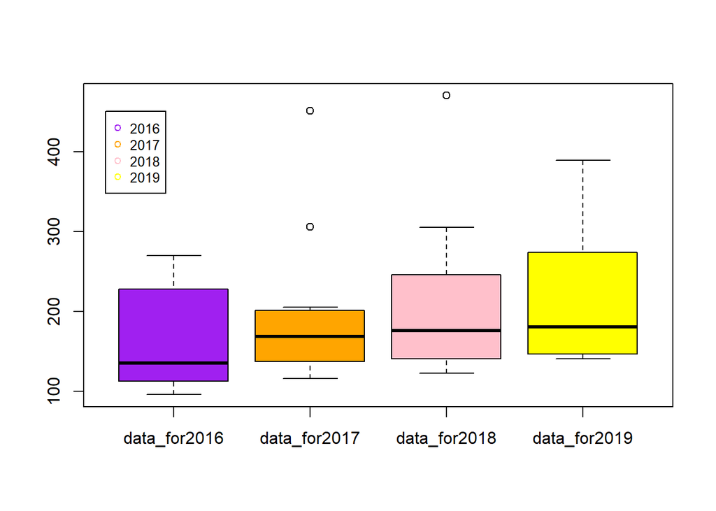

When two boxplots are analyzed comparatively,It can be difficult to talk about the similarity of trends and a direct positive correlation.While it is relatively difficult to establish a relationship between the two data sets, when the data set obtained from google is examined separately, an increasing trend can be seen in recent years. From here, it can be said that while there is a possibility to make an inference as the use of internet for hotel reservations has increased, many more different information and data that can be associated will be needed to reach such a result.

## Total housing credit(thousand liras)

This data set gives us information about the total housing credit on a monthly basis between 2016 and 2019.Such data can be affected by many different variables such as loan interest rates. In order to see and analyze the distribution of the data, the information is placed in separate histograms for each year. Check [Here](http://www.tcmb.gov.tr/wps/wcm/connect/af2e86c3-6410-45ce-9eb6-1770e459b528/Metaveri.pdf?MOD=AJPERES&CACHEID=ROOTWORKSPACE-af2e86c3-6410-45ce-9eb6-1770e459b528-msdty8M) for extra information.

*Year by Year Histograms*

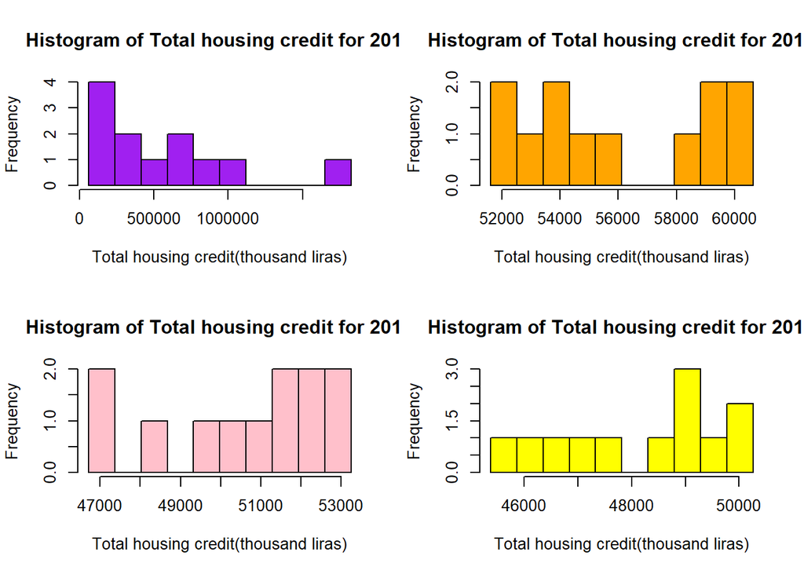

When these data were placed on a single boxplot, it was difficult to examine the range of other years as the data range in 2016 was very wide.Therefore,the data was examined for all years on seperate boxplots in order to better observe the change between years and data intervals.

*Boxplot of data*

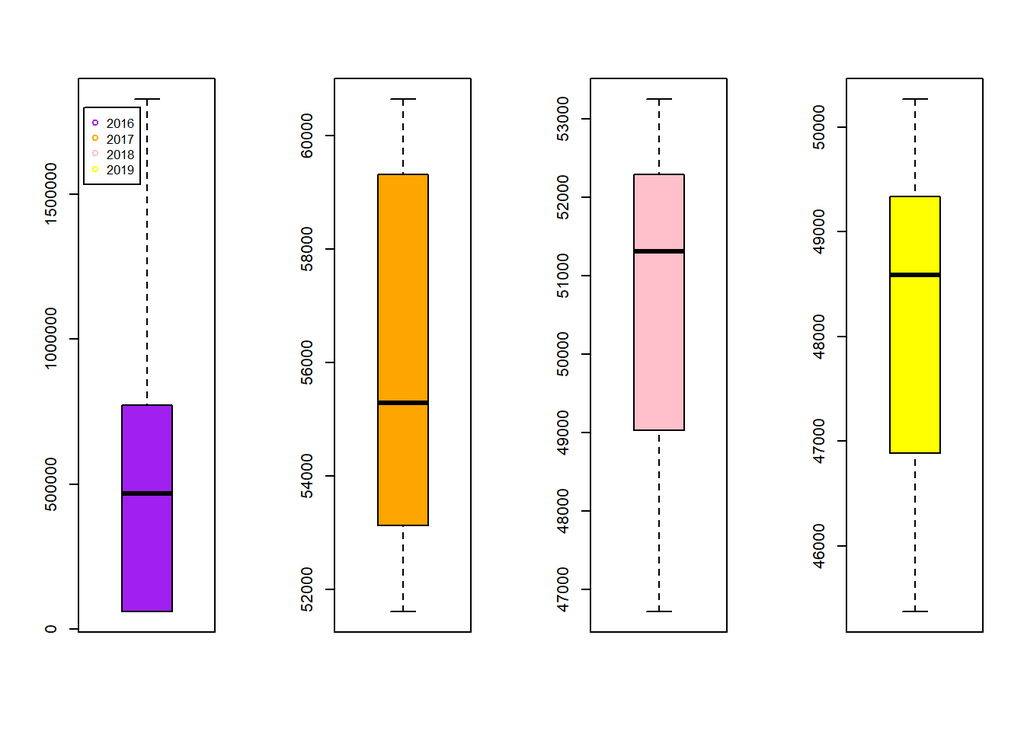

When the boxplot is examined, it can be easily observed that there is a noticeable difference between the data of the years, while 2016’s data follows a rather distant pattern in others,It can be said that the averages of 2017 and 2018 are close.

[Google Trends](http://trends.google.com/) data can be used to investigate the link between total housing credits and the serach volume of “satılık ev”. This comparison can be helpful to get an idea of how much home buyers use the internet for research.

*Boxplot of Google Trends data*

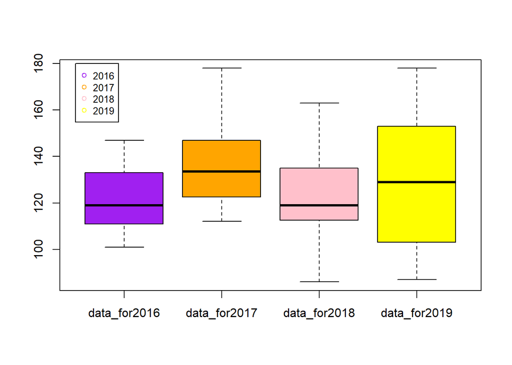

When two boxplots are analyzed comparatively,It can be difficult to talk about the similarity of trends. It does not seem logical to establish a direct link between these two data, there may be a lot of data that can be included in this relationship. For example, loan rates over the years, changes in the reliability of websites for home searches, some other fluctuations in the real estate industry, and more.